# Vectores y Factores en R

Ricardo Macías Bohórquez

11 de October de 2024

# Introducción a Vectores y Factores

En esta clase, exploraremos dos de las estructuras de datos fundamentales en R: **vectores** y **factores**. Comprender estas estructuras es esencial para manipular y analizar datos de manera eficiente.

## 1. Vectores en R

Un **vector** es una colección de elementos del mismo tipo. Es la estructura de datos más básica en R y es esencial para manejar datos numéricos, de caracteres o lógicos.

### 1.1 Creación de Vectores

#### Con la función `c()`

La función `c()` (concatenar) se utiliza para crear vectores combinando elementos individuales.

```r
# Vector numérico
numeros <- c(1, 2, 3, 4, 5)
print(numeros)
```

```
## [1] 1 2 3 4 5
```

```r
# Vector de caracteres
frutas <- c("manzana", "banana", "cereza")
print(frutas)
```

```
## [1] "manzana" "banana"  "cereza"
```

```r
# Vector lógico
logicos <- c(TRUE, FALSE, TRUE)
print(logicos)
```

```
## [1]  TRUE FALSE  TRUE
```

#### Usando operadores y funciones

- **Operador `:`**: Crea secuencias de números enteros.

  ```r
  # Números del 1 al 10
  secuencia1 <- 1:10
  print(secuencia1)
  ```

  ```
  ##  [1]  1  2  3  4  5  6  7  8  9 10
  ```

- **Función `seq()`**: Crea secuencias con incrementos definidos.

  ```r
  # Números del 0 al 1 con incrementos de 0.1
  secuencia2 <- seq(0, 1, by = 0.1)
  print(secuencia2)
  ```

  ```
  ##  [1] 0.0 0.1 0.2 0.3 0.4 0.5 0.6 0.7 0.8 0.9 1.0
  ```

- **Función `rep()`**: Repite elementos.

  ```r
  # Repetir "A" 5 veces
  repeticiones <- rep("A", times = 5)
  print(repeticiones)
  ```

  ```
  ## [1] "A" "A" "A" "A" "A"
  ```

### 1.2 Manipulación de Vectores

#### Accediendo a elementos

Utilizamos corchetes `[]` para acceder a elementos o subconjuntos.

```r
# Vector original
print(numeros)
```

```
## [1] 1 2 3 4 5
```

```r
# Primer elemento
numeros[1]
```

```
## [1] 1
```

```r
# Del segundo al cuarto elemento
numeros[2:4]
```

```
## [1] 2 3 4
```

```r
# Excluir el tercer elemento
numeros[-3]
```

```
## [1] 1 2 4 5
```

#### Operaciones vectorizadas

Las operaciones se aplican a cada elemento del vector.

```r
# Sumar 2 a cada elemento
numeros + 2
```

```
## [1] 3 4 5 6 7
```

```r
# Multiplicar vectores
numeros * c(2, 2, 2, 2, 2)
```

```
## [1]  2  4  6  8 10
```

#### Filtrado de vectores

Podemos filtrar elementos basados en condiciones lógicas.

```r
# Elementos mayores que 3
numeros[numeros > 3]
```

```
## [1] 4 5
```

```r
# Posiciones donde el valor es TRUE
logicos[logicos == TRUE]
```

```
## [1] TRUE TRUE
```

## 2. Factores en R

Los **factores** son estructuras de datos utilizadas para almacenar datos categóricos. Son especialmente útiles en análisis estadísticos y gráficos.

### 2.1 Creación de Factores

Utilizamos la función `factor()` para crear factores.

```r
# Datos categóricos
colores <- c("rojo", "azul", "verde", "rojo", "azul")
print(colores)
```

```
## [1] "rojo"  "azul"  "verde" "rojo"  "azul"
```

```r
# Convertir a factor
factor_colores <- factor(colores)
print(factor_colores)
```

```
## [1] rojo  azul  verde rojo  azul
## Levels: azul rojo verde
```

#### Verificar niveles

```r
levels(factor_colores)
```

```
## [1] "azul"  "rojo"  "verde"
```

### 2.2 Especificar niveles y orden

Podemos definir niveles y su orden, lo cual es útil para datos ordinales.

```r
# Datos de satisfacción
satisfaccion <- c("alta", "media", "baja", "alta")
print(satisfaccion)
```

```
## [1] "alta"  "media" "baja"  "alta"
```

```r
# Crear factor con orden
factor_satisfaccion <- factor(satisfaccion, levels = c("baja", "media", "alta"), ordered = TRUE)
print(factor_satisfaccion)
```

```
## [1] alta  media baja  alta
## Levels: baja < media < alta
```

#### Verificar niveles y orden

```r
levels(factor_satisfaccion)
```

```
## [1] "baja"  "media" "alta"
```

```r
is.ordered(factor_satisfaccion)
```

```
## [1] TRUE
```

### 2.3 Manipulación de Factores

#### Cambiar nombres de niveles

```r
# Niveles actuales
levels(factor_colores)
```

```
## [1] "azul"  "rojo"  "verde"
```

```r
# Cambiar nombres de niveles
levels(factor_colores) <- c("Azul", "Rojo", "Verde")
print(factor_colores)
```

```
## [1] Rojo  Azul  Verde Rojo  Azul
## Levels: Azul Rojo Verde
```

#### Convertir factores a caracteres o numéricos

```r
# A caracteres
as.character(factor_colores)
```

```
## [1] "Rojo"  "Azul"  "Verde" "Rojo"  "Azul"
```

```r
# A numéricos (índices de niveles)
as.numeric(factor_colores)
```

```
## [1] 2 1 3 2 1
```

## 3. Ejemplos Prácticos

### **Ejemplo 1**: Análisis de calificaciones

Supongamos que tenemos las calificaciones de estudiantes:

```r
# Calificaciones
calificaciones <- c(90, 75, 88, 60, 95)
print(calificaciones)
```

```
## [1] 90 75 88 60 95
```

#### Clasificar calificaciones

Queremos clasificar las calificaciones en “Aprobado” y “Reprobado”.

```r
# Crear factor
estado <- factor(ifelse(calificaciones >= 70, "Aprobado", "Reprobado"))
print(estado)
```

```
## [1] Aprobado  Aprobado  Aprobado  Reprobado Aprobado
## Levels: Aprobado Reprobado
```

```r
# Ver resultados
table(estado)
```

```
## estado
##  Aprobado Reprobado
##         4         1
```

### **Ejemplo 2**: Encuestas de opinión

Datos de opiniones:

```r
# Opiniones
opiniones <- c("De acuerdo", "En desacuerdo", "Neutral", "De acuerdo")
print(opiniones)
```

```
## [1] "De acuerdo"    "En desacuerdo" "Neutral"       "De acuerdo"
```

#### Convertir a factor ordenado

```r
# Crear factor ordenado
factor_opiniones <- factor(opiniones, levels = c("En desacuerdo", "Neutral", "De acuerdo"), ordered = TRUE)
print(factor_opiniones)
```

```
## [1] De acuerdo    En desacuerdo Neutral       De acuerdo
## Levels: En desacuerdo < Neutral < De acuerdo
```

## 4. Ejercicios Prácticos

### **Ejercicio 1**: Creación y manipulación de vectores

Crea un vector con los números impares del 1 al 19. Luego, multiplica cada elemento por 2.

```r
# Tu código aquí
```

**Mostrar solución**

```r
# Crear vector de números impares
impares <- seq(1, 19, by = 2)
print(impares)
```

```
##  [1]  1  3  5  7  9 11 13 15 17 19
```

```r
# Multiplicar por 2
resultado <- impares * 2
print(resultado)
```

```
##  [1]  2  6 10 14 18 22 26 30 34 38
```

### **Ejercicio 2**: Trabajando con factores

Tienes los siguientes datos de nivel educativo:

```r
educacion <- c("Secundaria", "Universidad", "Primaria", "Universidad", "Secundaria")
print(educacion)
```

```
## [1] "Secundaria"  "Universidad" "Primaria"    "Universidad" "Secundaria"
```

Convierte este vector en un factor ordenado de menor a mayor nivel educativo.

```r
# Tu código aquí
```

**Mostrar solución**

```r
# Crear factor ordenado
factor_educacion <- factor(educacion, levels = c("Primaria", "Secundaria", "Universidad"), ordered = TRUE)
print(factor_educacion)
```

```
## [1] Secundaria  Universidad Primaria    Universidad Secundaria
## Levels: Primaria < Secundaria < Universidad
```

```r
# Verificar niveles
levels(factor_educacion)
```

```
## [1] "Primaria"    "Secundaria"  "Universidad"
```

### **Ejercicio 3**: Análisis de datos categóricos

Supongamos que realizaste una encuesta sobre preferencias de colores:

```r
colores_encuesta <- c("Azul", "Verde", "Rojo", "Azul", "Verde", "Verde")
print(colores_encuesta)
```

```
## [1] "Azul"  "Verde" "Rojo"  "Azul"  "Verde" "Verde"
```

Convierte los datos a factor y muestra un gráfico de barras de las frecuencias.

```r
# Tu código aquí
```

**Mostrar solución**

```r
# Convertir a factor
factor_colores_encuesta <- factor(colores_encuesta)
print(factor_colores_encuesta)
```

```
## [1] Azul  Verde Rojo  Azul  Verde Verde
## Levels: Azul Rojo Verde
```

```r
# Tabla de frecuencias
tabla_colores <- table(factor_colores_encuesta)
print(tabla_colores)
```

```
## factor_colores_encuesta
##  Azul  Rojo Verde
##     2     1     3
```

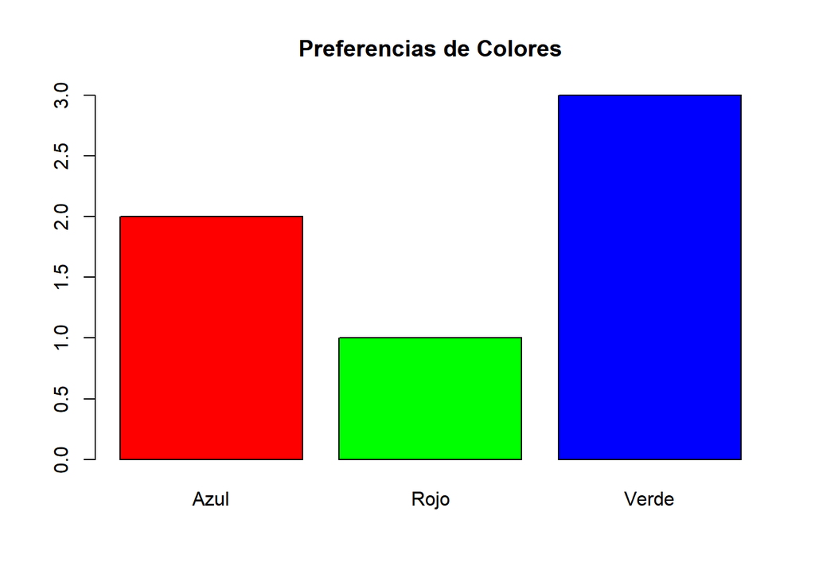

```r
# Gráfico de barras
barplot(tabla_colores, main = "Preferencias de Colores", col = rainbow(length(tabla_colores)))
```

## 5. Buenas Prácticas

- **Uso correcto de factores**: Siempre especifica los niveles y el orden si es relevante para tu análisis.
- **Consistencia en los datos**: Asegúrate de que los datos categóricos estén estandarizados (por ejemplo, evitar “Si” y “sí” como niveles diferentes).
- **Comentarios y documentación**: Añade comentarios a tu código para mejorar la legibilidad y mantenimiento.